# Seattle Criminals Don’t Mind the Rain

Patricia Tressel

January 25, 2016

## The Question…

Are some crimes less likely to happen when it’s raining…or more likely? Do criminals prefer rain, or avoid it, for particular crimes?

Seattle is notorious for its rain. I live in Seattle, and can attest to the rain…though it’s less prevalent than its reputation would have one believe. Nevertheless, Seattle has a good mix of rainy and sunny weather, so provides an opportunity for exploring weather-dependent activity choices…including crimes.

This is an attempt to explore whether some crimes are less, or more, likely than others to happen during the rain. Perhaps some crimes are hindered by rain, or criminals, like other folks, just tend to stay inside when it’s raining. On the other hand, perhaps some criminals find rain provides cover for their activities. Is there a relationship between rain, and whether the crime is typically performed outdoors?

The focus here is on human exploration of the data, and the use of visualization to convey information, rather than automated analysis. So there will be at least as much discussion of how to display the information as there is about the question of crime versus rain.

## Sources of data

### Crime data

This uses four years of crime data, for the years 2012 through 2015, obtained from:

https://data.seattle.gov/Public-Safety/Seattle-Police-Department-Police-Report-Incident/7ais-f98f

The fields from this dataset that will be used here are:

- Summarized.Offense.Description: the crime category
- Occurred.Date.or.Date.Range.Start: the starting date of the crime

(Note to fellow students in Dr. Howe’s Communicating Data Science Results course: This is not the supplied dataset, but rather is a superset of it, from the same source.)

### Weather data

Data on daily precipitation is from Weather Underground, for their nearest reference location, which is at the Boeing airfield south of downtown Seattle.

http://www.wunderground.com/history/airport/KBFI/2012/1/1/CustomHistory.html

(The above URL shows one day of data – to obtain more, set the ending date as well.)

This dataset contains meteorological information for each day, incuding:

- PrecipitationIn: the total precipitation that day, in inches
- Events: a set of binary flags indicating rain, snow, thunderstorm, fog.

## Reproducing these results

The source for this document is available here:

https://github.com/ptressel/seattle_crime_vs_rain

This document is generated from an R markdown file containing runnable code, that can be processed to produce this document. It would be good to look at the document source while reading this, so please open the source here:

https://github.com/ptressel/seattle_crime_vs_rain/seattle_crime_vs_rain.Rmd

If you would like to run this, first clone or download the git repository linked above. In addition to the R markdown file, the repository contains he crime and weather data.

You will need the current versions of R and RStudio, and the following R packages:

- ggplot2
- lubridate
- plyr
- reshape2
- (Other packages that the above are dependent on, which will be installed along with the above packages.)

Start RStudio, change the directory to the repository, open the file seattle_crime_vs_rain.Rmd, and click Knit HTML. This is not running large statistical computations or training machine learning models, so should run fairly quickly. As always, for security, please examine carefully any code before you run it.

All code blocks are hidden. If you would like to see this with the interleaved code, remove the echo=FALSE from each {r …} code chunk header. You can also remove cache=TRUE to avoid having this write intermediate results out to disk.

Ok! Let’s get started!

## What we’re attempting…and a request for advice

This is intended to *visually* explore the relationship between occurrence of various crime types, and the amount of rain on the same day. This is chosen precisely because it is an awkward visualization task, for these reasons:

- There are many categories. This makes for visual clutter and over-long plots or charts.
- Because the identity of the categories is important – we want to see whether they may be “indoor” or “outdoor”, or have some other rain-related features in common – the names need to be shown.
- There is only one other dimension – rain – against which the category is being compared. Having at least two dimensions of numerical data allows displays like scatterplots that are visually informative – they spread out the data and allow one to more easily see patterns.

So, I’d like to ask any students who are reviewing this for Dr. Howe’s class, please leave recommendations somewhere in the review, or come find me online in the course forum. Here are some questions on which I’d like your opinion and suggestions:

- How would you change the current visualizations?
- Can you think of other ways of visually comparing the crime categories and amount of precipitation?
- In addition to the main categories, there are many more crime subtypes within the main categories. What sort of display might accommodate those?
- Would an interactive display be useful? For instance:
  - Something that allows collapsing part of a display, and zooming in on the rest?
  - Or that allows combining categories into groups to merge together?
  - Or that starts with details hidden, and allows the user to request additional information?

Thanks!

## Some notes on the data

Seattle has little snow, and snow is, if anything, more disruptive than rain (especially in Seattle, where people have little experience dealing with it, and the entire city grinds to a halt…). The weather dataset does not distinguish rain and snow in the amount of precipitation it reports.

In the weather dataset, each day is assigned one or more binary flags in the Events field: Rain, Snow, Thunderstorm, Fog. It is not clear what the purpose of the flags are. In particular, the Rain flag is not related to some level of precipitation for the day – the Rain flag is found on days with zero precipitation. For this reason, the Rain flag was abandoned as unreliable, and we’ll rely on the amount of precipitation.

The precipitation values are in inches per day, and range from 0.0 to 2.49. They are limited to two places of accuracy to the right of the decimal point. Over the four years of data, 58 % have no precipitation at all. The distribution of precipitation amounts on days that have any precipitation is:

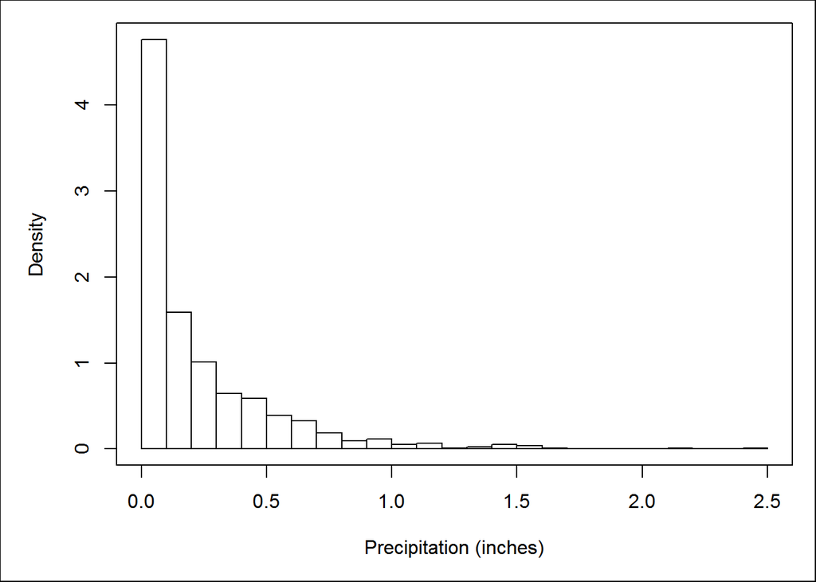

The crime dataset has two fields for types of offenses. One, Summarized.Offense.Description, has 56 values, and the other, Offense.Type, has 184 values. The Offense.Type values are nested under the Summarized.Offense.Description values, i.e. the Summarized.Offense.Description values are main categories, and the Offense.Type values are subtypes.

Among the main categories are several that are bookkeeping or operational types, rather than crimes, such as warrants being served. Others are rare. We have 346177 records in the crime data, over four years. We’ll drop categories that have fewer than 100 records, which means there are fewer than 25 of those offenses per year on average. With those changes, we’re left with 39 crime categories. That is still a lot of categories to squeeze into one plot or chart. For now, we’ll look only at those main categories rather than the subtypes.

## Approaches

In order to see if some crimes are associated with rain and others with the lack of rain, we can view this question from (at least) two directions:

- How much rain is typically present when each sort of crime is perpetrated?
- For different amounts of rain, how frequent is each crime?

### Is there a difference in precipitation per crime category?

For each crime category, we aggregate and compute summary statistics on the daily precipitation.

Because a majority of days have no rain, the median amount of rain for most categories is zero, which renders the median useless for displaying how much rain is present per category. Instead, we’ll use the mean precipitation per day.

We’ll also want to show how variable the amount of rain is per category – if we just show the mean, that’s misleading if the samples for that category aren’t closely centered about the mean. As it turns out, the range of precipitation amounts is quite broad for nearly all categories. It’s common to show the 25% and 75% quantiles to show the spread, but as with the median, that is not very informative – the lower quartile is nearly always zero, and the upper quartiles tend to be at about the same value. Instead, we’ll display the spread by showing a bar the length of the standard deviation, on either side of the mean, but truncated at the limits of the precipitation values.

In addition to the location and spread of the precipitation values, we’d like to also indicate how reliable each category’s information is. That is, how many samples do we have for that category? If we have lots of examples of some crime category, we can have more confidence that its mean is not just a quirk of this dataset. To show this, the marker showing the mean is colored by the frequency of the category. This doesn’t have to be precise – it’s just to indicate which categories are better supported by the data.

NOTE: The use of color here is entirely deliberate. I disagree strongly that color can never be used to indicate magnitude. It is *frequently* so used in the physical sciences. If you’ve seen a weather report on television, you’ve likely seen color used to indicate temperature on a map. Color is used to show magnitude of a continuous function over a two-dimensional area. On a rendering of a 3D object, color can be used to show stress or heat levels.

If you’re in Dr. Howe’s class, please see this discussion thread for more:

https://www.coursera.org/learn/data-results/discussions/TEzHHb6WEeWlQwoU9G612w

If you’re reviewing this, I’d like your opinion on this particular use of color. Come join the discussion in the forum – do you think color can be used for magnitude? or would you try to avoid it? or would you never, ever so use it?

This will be rendered as a web page, not a PDF file, in order to avoid issues with margins and page breaks that could interfere with large plots. Because it’s easier to scroll vertically, and easier to read English text when it’s horizontal, the plot will show the categories along the Y axis.

The categories are ordered by mean, with the largest at the top. This makes it easier to see if there are any patterns or breaks. So, have a look, and then we’ll draw some conclusions below.

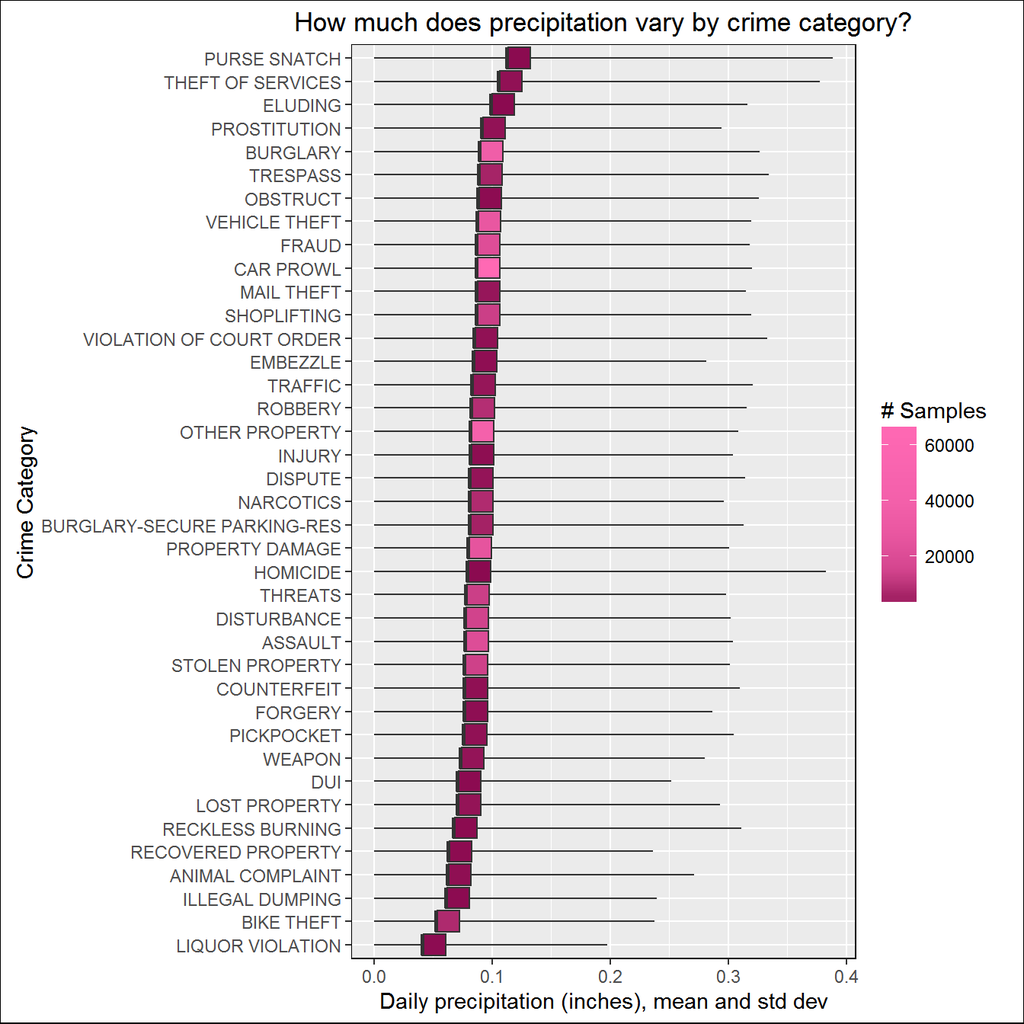

So…the mean precipitation per crime category is not the same for all categories. Does that mean we should proclaim that some crimes are better in the rain? That when it rains, the police should be out watching for purse snatchers? Maybe rain and gloom provides cover for crime? But no…bike theft – surely an outdoor crime – is at the low precipitation end.

But are we being mislead by the precipitation scale? By how much do those means actually differ, and is that large compared to some meaningful scale? What we need to look at is the *effect size*. This is not related to statistical significance – an effect can be highly significant, and still be utterly trival in magnitude.

The difference between the highest and lowest mean is 0.07. Is that a lot or a little? What should we use for a scale? One scale is the standard deviation of daily precipitation, 0.22. The means differ by about 0.33 of that standard deviation. (Remember, we’re not talking about significance here, so we don’t want to use the standard deviation of the mean as a scale – that can be made arbitrarily small by including more samples.)

Perhaps a better scale would be the standard deviations for each category, shown by the bars around each mean in the above plot. We can see that the entire range of means falls within one standard deviation of the others, for the standard deviation of any category.

As we’ll see in the next section, the span of the category means is about the size of precipitation ranges used for standard descriptions of rainfall – light, moderate, heavy. So by two measures derived from the data, the differences aren’t large, though the amount is about what distinguishes light from moderate rain.

### How often do crimes happen, per amount of precipitation?

Let’s try looking at this from the other side: Start with how much precipitation there is, and see how often each category is associated with each amount of precipitation. How can this be visualized?

We could consider a scatterplot – plot category versus precipitation. Each category could be given its own line, and the points be jittered and made transparent, so they are darker and denser when there are more points. But still, the points are along single lines, and density of points is problematic when they are stacked directly on top of each other, as they are here with the limited precision of the precipitation values. Even with jittering and halos, the points are discrete – we’re relying on having many of them to smooth out the density.

Another option would be to bin the precipitation values coarsely, and show stacked bargraphs with a bar for each category, and bands for each precipitation level. Since the bars are more broad than the lines of points above, and the levels will have definite cutoffs, this should be more precise than the overlapped points above.

We don’t want to obscure the relationship with precipitation by making more frequent crimes more prominent, so we can make all the bars the same height. That is, we can show the relative frequency – the fraction of time that the crime is done in each precipitation level.

So, we want to bin the samples into precipitation “levels” – what shall we use for those? Too many levels will make the bargraph messy. And what is the difference, really, between 0.11 and 0.12 inches per day of rain? Fortunately, there are some fairly standard ways of grouping precipitation. It’s common for weather forecasts to say rain will be light, moderate, or heavy, and, it turns out, there are definitions for those terms. We’ll use the definitions provided here:

https://www.weathershack.com/static/ed-rain-measurement.html

- light: less than 0.01 inches / hour
- moderate: from 0.01 to 0.03 per hour
- heavy: greater than 0.03 / hour

For precipitation per day, that means:

- light: less than 0.01 * 24 = 0.24 inches / day
- moderate: from 0.24 to 0.72 inches / day
- heavy: greater than 0.72 inches / day

Since we’ve seen that most days have no rain, we’ll add a level just for that:

- none: identically 0.0 inches / day

As with the previous plot, it will be easier to understand this if the categories are ordered in some way by the precipitation variable. But unlike the previous case, we have several options. We could order by where one of the dividing lines between precipitation levels is. Or, we could order by the width of one of the levels. We should pick something that is meaningful to the question of criminal activity. Folks in Seattle, presumably including criminals, aren’t bothered by a little rain. So, treat no rain and light rain as levels that we don’t expect to have in impact, where moderate and heavy might. Order the categories by the height of the division between light and moderate. (We could try splitting at the other divisions as well, but showing this one case should give us an idea of whether this type of display work at all.)

And with those choices, let’s see what it looks like.

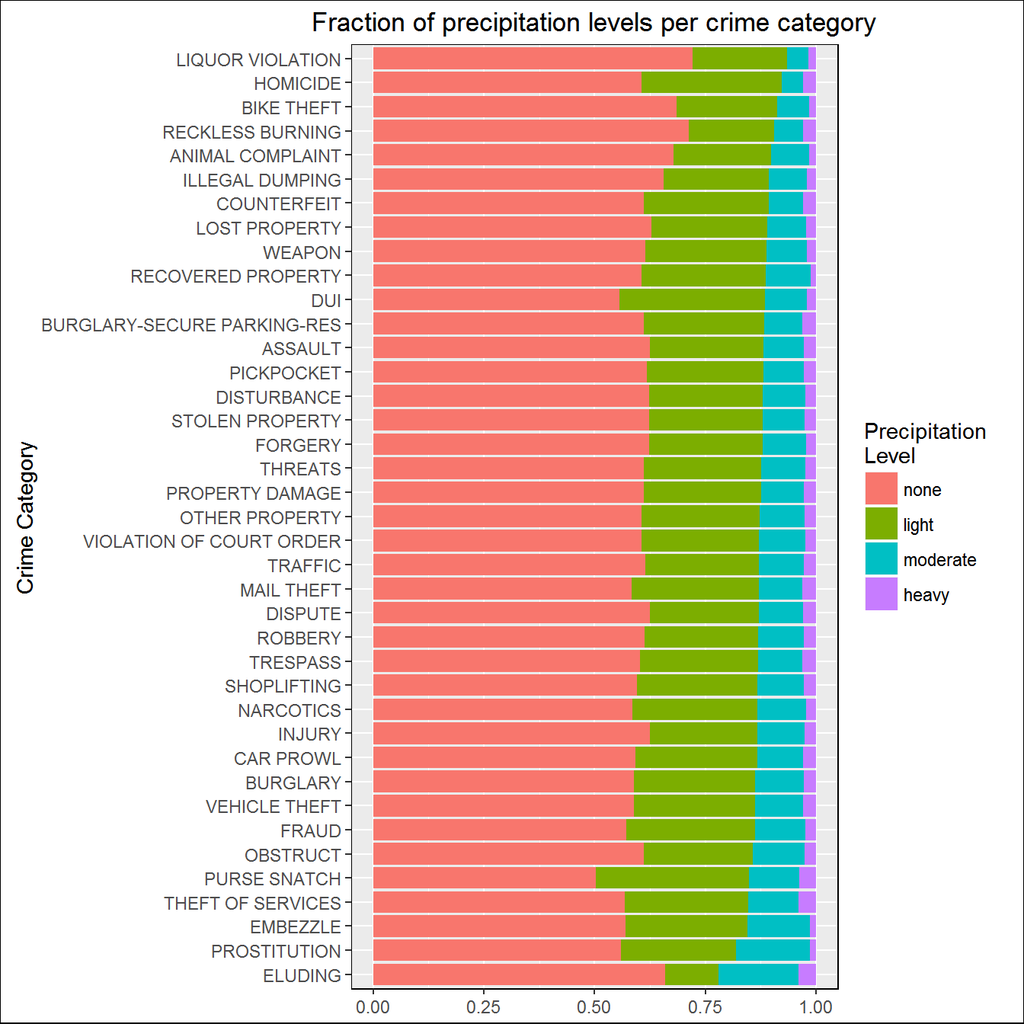

Again, we see crimes that might be considered outdoor activites (bike theft, car prowl) at opposite ends. And nor does any pattern leap out, in how prevalent the precipitation levels are per crime category.

## Conclusion

Long-time Seattle residents are known for ignoring the rain. So it’s not surprising that, overall…

Seattle criminals just don’t care if it’s raining.

(Remember, suggestions are welcome!!)